# Machine Learning Evaluation of Correct Weight Lifting Form

Wayne Carriker

## Executive Summary

In this assignment we look at data from the Human Activity Recognition (HAR) project and attempt to use accelerometer data from several sensors to evaluate if an individual is performing a specific exercise correctly or making one of several common mistakes. We determine that a C5.0 classification algorithm using a subset of the data is able to correctly identify over 99% of a test set of data. We then apply that machine learning model to the assignment test cases and achieve 100% (20 of 20) first time matches.

## Exploratory Analysis

The first thing we consider is the data to be used in this analysis. Simply opening the file in a text editor or Excel allows us to see that the majority of the columns are mostly blank or NA and can be dropped before beginning our “real” analysis. Several others can be eliminated because they are related to the time of the sample or the specific individual being measured. This leaves fifty-two (52) possible predictors in addition to the output.

```r
# Load the raw data from the .CSV file and eliminate all the columns that
# are not useful

raw_data <- read.csv("pml-training.csv")
no <- grep("^amp|^avg|^kur|^max|^min|^skew|^std|^user|^var|time|window$|^X$",
           names(raw_data))
full_data <- raw_data[,-no]
```

Before beginning further analysis, we split the data into a training set (60%), a validation set (20%), and a final test set (20%). We then create feature plots of the remaining possible predictors (one such plot is shown below) to evaluate the likely value of different possible predictors.

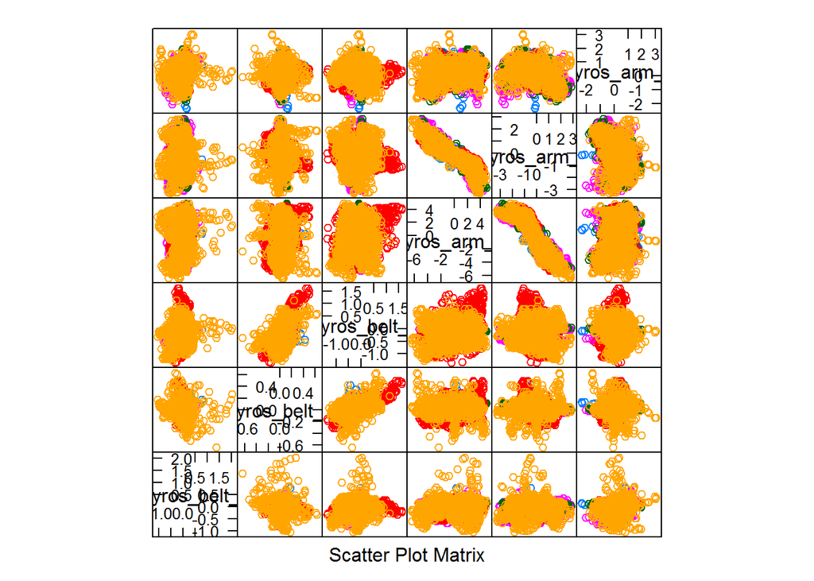

```r
# Load the libraries needed for this evaluation

library(lattice, quietly=TRUE, verbose=FALSE, warn.conflicts=FALSE)
library(ggplot2, quietly=TRUE, verbose=FALSE, warn.conflicts=FALSE)
library(caret, quietly=TRUE, verbose=FALSE, warn.conflicts=FALSE)

# Now, split the data into training, validation, and final test sets before
# further evaluation of the data

set.seed(964)
inTrain <- createDataPartition(y=full_data$classe, p=0.6, list=FALSE)
full_training <- full_data[inTrain,]
other <- full_data[-inTrain,]
inTest <- createDataPartition(y=other$classe, p=0.5, list=FALSE)
full_testing <- other[inTest,]
full_validation <- other[-inTest,]

fplot <- featurePlot(x=full_training[,c("gyros_belt_x","gyros_belt_y",
                                        "gyros_belt_z", "gyros_arm_x",
                                        "gyros_arm_y", "gyros_arm_z")],
                     y=full_training$classe, plot="pairs")
```

In this case, we determine that there does not appear to be any way discriminate one output from another based on the raw gyros, accelerometer, or magnet data. This leaves 16 possible predictors: roll, pitch, yaw, and total acceleration from each of the four sensors on the belt, arm, dumbbell, and forearm.

```r
simpler <- grep("roll|pitch|yaw|total|classe", names(full_data))
training <- full_training[,simpler]
validation <- full_validation[,simpler]
testing <- full_testing[,simpler]
```

We now have a training data set consisting of 11776 observations of 16 predictors and 1 output, a validation set consisting of 3923 observations and a final test set consisting of 3923 observations. The caret package in R provides 192 different machine learning algorithms to choose from, of which 147 can be used to build a classification model. Given limited time, we can’t explore them all, so somewhat arbitrarily we choose to try 10 of them: Bagged AdaBoost (AdaBag), C5.0, a Rule-Based Classifier (JRip), k-Nearest Neighbors (knn), a Neural Network (nnet), a Single Rule Classifier (OneR), another Rule-Based Classifier (PART), a Random Forest (rf), CART (rpart), and a Support Vector Machine with Linear Kernal (svmLinear). The code for performing these runs can be found in the Appendix.

As shown in the table below, build time for the individual models ranges from just a few seconds to the better part of an hour (with a 2.6 GHz i5 processor and 4GB of memory), performance against the validation data set ranges from 41.7% to 99%, and build time is not well correlated with accuracy. The AdaBag algorithm took the longest time to build a model yet had the third worst performance, while the PART and knn algorithms took just over a minute and produced the third and fifth best results.

| Algorithm | Accuracy | Build Time |
| --- | --- | --- |
| ————— | ————— | —————– |
| AdaBag | 44.3% | 45 min |
| ————— | ————— | —————– |
| C5.0 | 99% | 20.2 min |
| ————— | ————— | —————– |
| JRip | 93.4% | 20.6 min |
| ————— | ————— | —————– |
| knn | 92.4% | 1.4 min |
| ————— | ————— | —————– |
| nnet | 41.7% | 11.8 min |
| ————— | ————— | —————– |
| OneR | 56.7% | 0.3 min |
| ————— | ————— | —————– |
| PART | 95.2% | 1.1 min |
| ————— | ————— | —————– |
| rf | 98.7% | 16.9 min |
| ————— | ————— | —————– |
| rpart | 44.2% | 0.3 min |
| ————— | ————— | —————– |
| svmLinear | 51.7% | 4.8 min |
| ————— | ————— | —————– |

## Additional Exploration

Given that we already identified 3 algorithms that produce better than 95% accuracy against the validation data set using the model defaults, we might be tempted to simply run the best one against the test set and be done. Instead, however, we will explore four alternatives: 1) can we improve on the model build times without impacting accuracy by further reducing predictors, 2) can we stack the top three models to improve accuracy, 3) can we improve the accuracy of the C5.0 algorithm by adding predictors, and finally 4) can we improve the accuracy of the C5.0 algorithm by combining the training and validation data? The code for each of these exercises can also be found in the Appendix.

In the first exercise we note that the total_accel_xxx predictors are correlated with the associated roll, pitch, and yaw predictors and thus they may not provide additional classification value. Eliminating these 4 variables reduces the problem to 12 predictors: roll, pitch, and yaw values for the belt, arm, dumbbell, and forearm sensors. As shown in the table below, however, repeating the top 5 algorithms (C5.0, rf, PART, JRip, and knn) results in little change in model creation times, 4 of the models (including the top 2) becoming slightly less accurate, and 1 of models actually improving, but not enough to change the order.

| Algorithm | Accuracy | Build Time |
| --- | --- | --- |
| ————– | ————————— | ——————-=————— |
| C5.0 | 99 > 98.7 | 20.2 min > 17.9 min |
| ————– | ————————— | ———————————– |
| rf | 98.7 > 98.6 | 16.9 min > 13.3 min |
| ————– | ————————— | ———————————– |
| PART | 95.2 > 95.7 | 1.1 min > 0.9 min |
| ————– | ————————— | ———————————– |
| JRip | 93.4 > 92.9 | 20.6 min > 17.3 min |
| ————– | ————————— | ———————————– |
| knn | 92.4 > 92 | 1.4 min > 1 min |
| ————– | ————————— | ———————————– |

In the next exercise we consider the value of stacking the top three models to determine if they can outperform the top model by itself. With five possible outputs for each observation, we cannot count on a majority decision for each case, so we consider the following: if all three rules agree, then we obviously accept that output; if any two of the rules agree, then we accept that output; if all three rules produce a different result, then we accept the output of the C5.0 model.

As shown in the table below, the combined approach actually results in worse performance against the validation set than the C5.0 algorithm alone. This indicates that the rf and PART models agree and are wrong while the C5.0 model is correct more often than they agree and are correct while the C5.0 model is incorrect. The code for this exercise is shown in the Appendix.

| Algorithm | Accuracy |
| --- | --- |
| ————– | ————- |
| C5.0 | 99 |
| ————– | ———— |
| rf | 98.7 |
| ————– | ———— |
| PART | 95.7 |
| ————– | ———— |
| stacked | 98.9 |
| ————– | ———— |

In the third and fourth exercises we will focus on the C5.0 algorithm and see if we can first improve the validation results by including more predictors and then what impact including more samples in the training set has on the accuracy against the final test set. The code for these exercises, as in the previous cases, is shown in the Appendix.

In the third case, we simply include the many predictors that were eliminated based on the feature plots. Using all 52 predictors results in building a C5.0 model in 53.8 minutes with an accuracy of 99.4%, which is a bit better than the initial value of 99% at a cost of more than two and a half times longer model build time.

In the final exercise, we include the validation data in the training data and compare the original model’s performance against the final test set with that of the same model type built with more training data. In this case, we use the models to predict the outcomes for multiple samples of the final test set in order to get a sense of the accuracy range. The results are shown in the table below:

| Algorithm | Test Accuracy | Accuracy Range |
| --- | --- | --- |
| ———————- | ————– | ——————- |
| C5.0 (original) | 98.8% | 98% - 99.4% |
| ———————- | ————– | ——————- |
| C5.0 w/ added samples | 99.3% | 98.6% - 99.7% |
| ———————- | ————– | ——————- |

To complete the assignment, we use our final algorithm to determine the correct classification of 20 test cases. This code is also in the Appendix.

## Conclusions

In this assignment we looked at data from the Human Activity Recognition (HAR) project and attempted to use accelerometer data from several sensors to evaluate if an individual is performing a specific exercise correctly or making one of several common mistakes. We determined that a C5.0 classification algorithm using a subset of the data is able to correctly identify 98.6% to 99.7% of a test set of data, and 100% (20 of 20) of the final assignment test cases.

## Appendix

### Initial Analysis

```r
# First, load all the libraries needed for different exercises

library(adabag, quietly=TRUE, verbose=FALSE, warn.conflicts=FALSE)
library(rpart, quietly=TRUE, verbose=FALSE, warn.conflicts=FALSE)
library(mlbench, quietly=TRUE, verbose=FALSE, warn.conflicts=FALSE)
library(plyr, quietly=TRUE, verbose=FALSE, warn.conflicts=FALSE)
library(C50, quietly=TRUE, verbose=FALSE, warn.conflicts=FALSE)
library(RWeka, quietly=TRUE, verbose=FALSE, warn.conflicts=FALSE)
library(nnet, quietly=TRUE, verbose=FALSE, warn.conflicts=FALSE)
library(randomForest, quietly=TRUE, verbose=FALSE, warn.conflicts=FALSE)
library(kernlab, quietly=TRUE, verbose=FALSE, warn.conflicts=FALSE)

# Loop through each of the ten machine learning methods and record the build
# times and accuracy values so they can be used in the report
method1 <- c("AdaBag", "C5.0", "JRip", "knn", "nnet",
             "OneR", "PART", "rf", "rpart", "svmLinear")
vlen <- length(validation$classe)
first_model <- vector("list", 10)
v1acc <- 1:10
exec1 <- 1:10
for (i in 1:10) {
    # Reset the random seed each time so that every model is built under the
    # same starting conditions
    set.seed(964)

    t1time <- proc.time()
    first_model[[i]] <- train(classe ~ ., method=method1[i], data=training)
    t2time <- proc.time()

    results <- predict(first_model[[i]], newdata=validation)
    v1acc[i] <- round(sum(results == validation$classe) / vlen * 100, 1)
    tdiff <- t2time - t1time
    exec1[i] <- round(as.integer(tdiff[3] - tdiff[2]) / 60, 1)
}
lacc <- v1acc[1]
hacc <- v1acc[1]
for (i in 2:10) {
    if (v1acc[i] < lacc) lacc <- v1acc[i]
    if (v1acc[i] > hacc) hacc <- v1acc[i]
}
```

### First Exercise

```r
# Reduce the training and validation data sets
simplest <- grep("^total", names(training))
simple_training <- training[,-simplest]
simple_validation <- validation[,-simplest]

# Loop through each of the five machine learning methods and record the build
# times and accuracy values so they can be used in the report
method2 <- c("C5.0", "rf", "PART", "JRip", "knn")
second_model <- vector("list", 5)
v2acc <- 1:5
exec2 <- 1:5
for (i in 1:5) {
    set.seed(964)

    t1time <- proc.time()
    second_model[[i]] <- train(classe ~ ., method=method2[i],
                               data=simple_training)
    t2time <- proc.time()

    results <- predict(second_model[[i]], newdata=simple_validation)
    v2acc[i] <- round(sum(results == simple_validation$classe) / vlen * 100, 1)
    tdiff <- t2time - t1time
    exec2[i] <- round(as.integer(tdiff[3] - tdiff[2]) / 60, 1)
}
```

### Second Exercise

```r
# No new models are needed - for this exercise we're just combining three
modelC50 <- first_model[[2]]
modelrf <- first_model[[8]]
modelPART <- second_model[[3]]
# Now build a table with the answers as well as the predictions from each model
answers <- as.data.frame(validation$classe)
answers$C50 <- predict(modelC50, newdata=validation)
answers$rf <- predict(modelrf, newdata=validation)
answers$PART <- predict(modelPART, newdata=simple_validation)
# Include the accuracies  for each of the models
C50acc <- round(sum(answers$C50 == validation$classe) / vlen * 100, 1)
rfacc <- round(sum(answers$rf == validation$classe) / vlen * 100, 1)
PARTacc <- round(sum(answers$PART == validation$classe) / vlen * 100, 1)
# Now create the stacked answers - start with just using the answers from C5.0
answers$final <- answers$C50
for (i in 1:vlen) {
    # if C5.0 == rf and rf == PART then the answer will stay C5.0
    # if C5.0 == rf or C5.0 == PART then the answer will stay C5.0
    # if rf == PART then the answer will switch to rf
    # if nothing matches then the answer will stay C5.0
    if (answers$rf[i] == answers$PART[i]) answers$final[i] <- answers$rf[i]
}
stackacc <- round(sum(answers$final == validation$classe) / vlen * 100, 1)
```

### Third Exercise

```r
# Time to build another model, this time using all the data

set.seed(964)
t1time <- proc.time()
fullmodel <- train(classe ~ ., method="C5.0", data=full_training)
t2time <- proc.time()

fullans <- predict(fullmodel, newdata=full_validation)
fullacc <- round(sum(fullans == full_validation$classe) / vlen * 100, 1)
tdiff <- t2time - t1time
fullbuild <- round(as.integer(tdiff[3] - tdiff[2]) / 60, 1)
```

### Fourth Exercise

```r
# Finally build the C5.0 model again with all the validation data too

set.seed(964)
big_training <- rbind(training, validation)
big_model <- train(classe ~ ., method="C5.0", data=big_training)

# Compute the accuracy against the entire test set for the original C5.0 and
# this one too

tlen <- length(testing$classe)
ans1 <- predict(first_model[[2]], newdata=testing)
firstacc <- sum(ans1 == testing$classe) / tlen
ans2 <- predict(big_model, newdata=testing)
secondacc <- sum(ans2 == testing$classe) / tlen

# Finally compute a range of accuracies by repeatedly sampling the test data

fla <- firstacc
fha <- firstacc
sla <- secondacc
sha <- secondacc
for (i in 1:100) {
    rows <- sample(1:tlen, 1000, replace=TRUE)
    right1 <- 0
    right2 <- 0
    for (j in 1:1000) {
        if (ans1[rows[j]] == testing$classe[rows[j]]) right1 <- right1 + 1
        if (ans2[rows[j]] == testing$classe[rows[j]]) right2 <- right2 + 1
    }
    thisacc1 <- right1 / 1000
    thisacc2 <- right2 / 1000
    if (thisacc1 < fla) fla <- thisacc1
    if (thisacc1 > fha) fha <- thisacc1
    if (thisacc2 < sla) sla <- thisacc2
    if (thisacc2 > sha) sha <- thisacc2
}
firstacc <- round(firstacc * 100, 1)
secondacc <- round(secondacc * 100, 1)
fla <- round(fla * 100, 1)
fha <- round(fha * 100, 1)
sla <- round(sla * 100, 1)
sha <- round(sha * 100, 1)
```

### Final Class Exercise

```r
# For the final class exercise, use the C5.0 model with 16 predictors and the
# full training + validation samples used for training

raw_test <- read.csv("pml-testing.csv")
no <- grep("^amp|^avg|^kur|^max|^min|^skew|^std|^user|^var|time|window$|^X$",
           names(raw_data))
test <- raw_test[,-no]
simpler <- grep("roll|pitch|yaw|total", names(test))
test <- test[,simpler]
test$classe <- rep("X",20)

for (i in 1:20) {
    fo <- file(sprintf("test%02i.txt",i), open = "w")
    writeLines(as.character(predict(big_model, newdata=test[i,])), fo)
    close(fo)
}
```

Report time: Sun Sep 20 04:05:03 2015 in 4.3 hours